# HW 3

Weiren Wang

February 19, 2018

### 3.8.1.1

```r
library(ggplot2)
```

# Section 3.8.1

### 1.

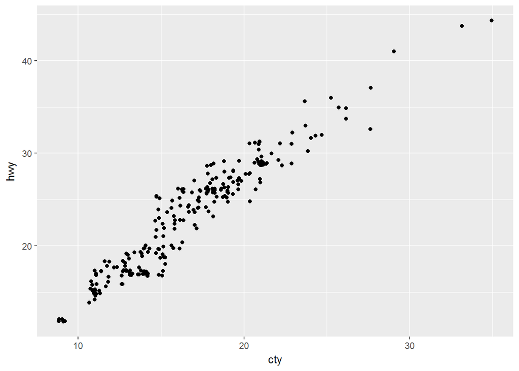

```r
ggplot(data = mpg, mapping = aes(x= cty, y= hwy))+
  geom_point(position = "jitter")
```

The values of cty and hwy are rounded so the points appear on a grid and many points overlap each other, which is known as overplotting. This problem can be avoided by setting the position adjustment to “jitter” which adds a small amount of random noise to each point. This spreads the points out because no two points are likely to receive the same amount of random noise. ### 2. width and height to geom_jitter() control the amount of jittering.

### 3.

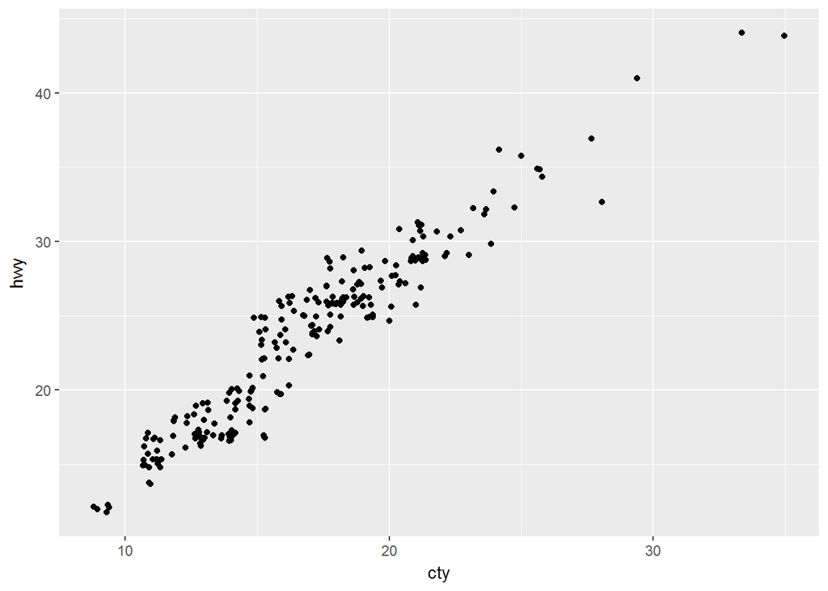

```r
ggplot(data = mpg, mapping = aes(x = cty, y= hwy))+
  geom_jitter()
```

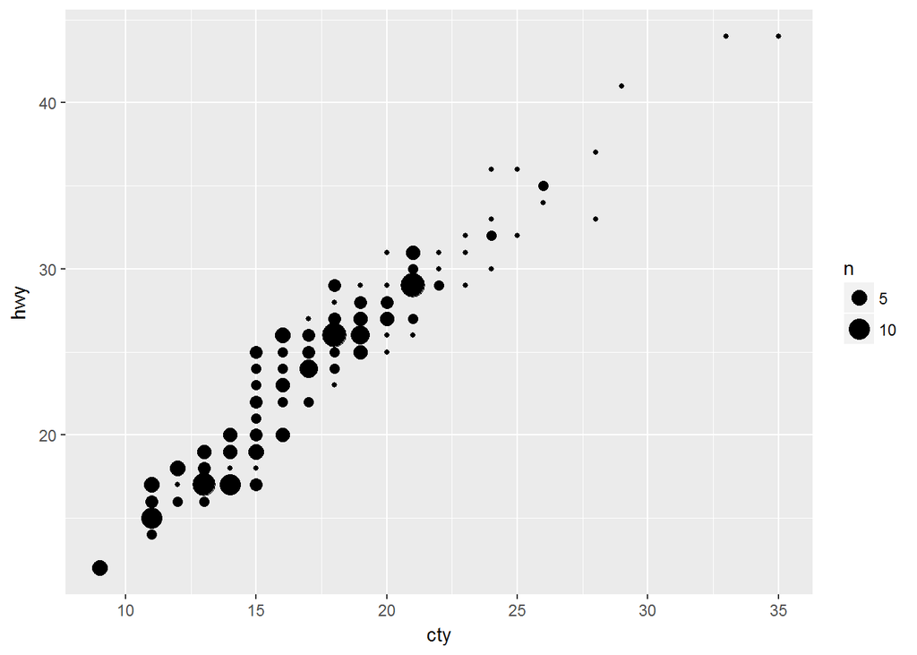

```r
ggplot(data = mpg, mapping = aes(x = cty, y= hwy))+
  geom_count()
```

geom_count() that counts the number of observations at each location, then maps the count to point area. It’s useful in discrete situations, but it doesn’t work when points are overlapping but not in exactly same place. geom_jitter() adds a small amount of random variation to the location of each point, and is a useful way of handling overplotting caused by discreteness in smaller datasets.

### 4.

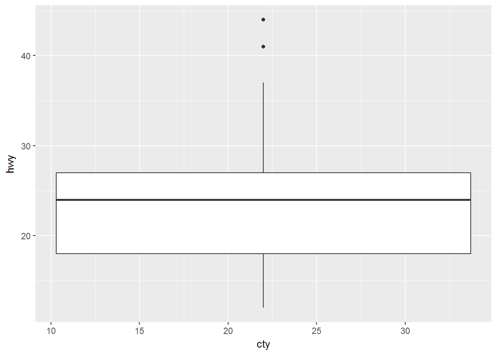

```r
ggplot(data = mpg, mapping = aes(x= cty, y= hwy, fill= cyl))+
  geom_boxplot()
```

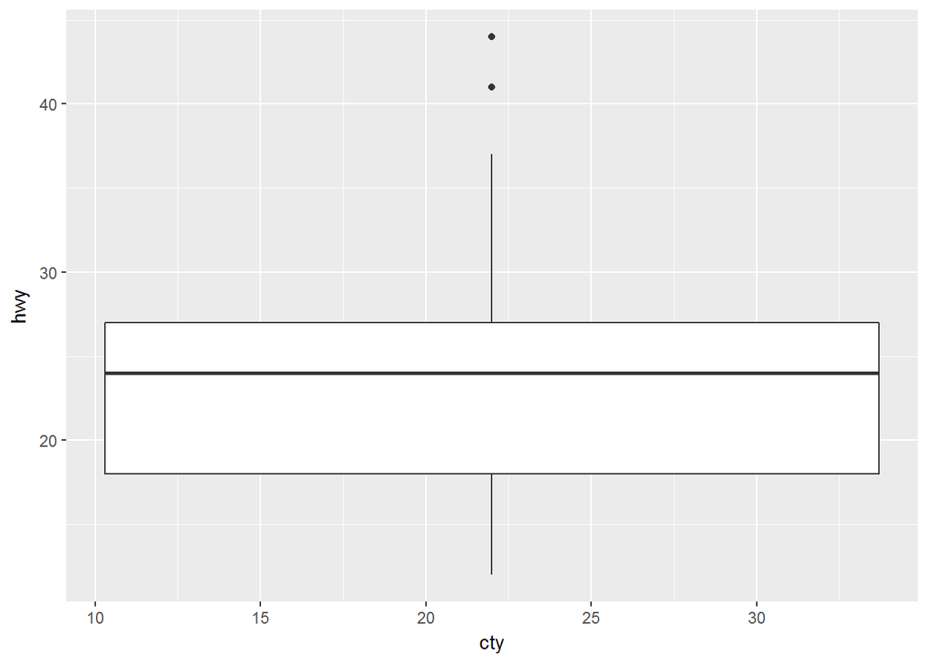

```r
ggplot(data = mpg, mapping = aes(x= cty, y= hwy, fill= cyl))+
  geom_boxplot(position = "dodge")
```

The default adjustment is position_ dodge.